# Lab: Linear Models and the infer Package

lm(), broom, and one grammar for every inference problem

## Getting started

Lecture covered *why* a slope has a sampling distribution. Today you will compute everything in code.

Two ideas to hold on to:

1. **A linear model is “just” a model.** `lm()` fits a line by least squares; everything after that (tests, intervals) is the same inference you already know.
2. **The `infer` package gives one grammar for all inference.** The same four verbs work for a proportion, a mean, a difference, and a slope.

```r
library(tidyverse)
library(openintro)
library(broom)
library(infer)
set.seed(401)
```

We use `births14` (births in the US in 2014) and `elmhurst` (gift aid at Elmhurst College).

```r
glimpse(births14)
```

```
Rows: 1,000
Columns: 13
$ fage           <int> 34, 36, 37, NA, 32, 32, 37, 29, 30, 29, 30, 34, 28, 28,…
$ mage           <dbl> 34, 31, 36, 16, 31, 26, 36, 24, 32, 26, 34, 27, 22, 31,…
$ mature         <chr> "younger mom", "younger mom", "mature mom", "younger mo…
$ weeks          <dbl> 37, 41, 37, 38, 36, 39, 36, 40, 39, 39, 42, 40, 40, 39,…
$ premie         <chr> "full term", "full term", "full term", "full term", "pr…
$ visits         <dbl> 14, 12, 10, NA, 12, 14, 10, 13, 15, 11, 14, 16, 20, 15,…
$ gained         <dbl> 28, 41, 28, 29, 48, 45, 20, 65, 25, 22, 40, 30, 31, NA,…
$ weight         <dbl> 6.96, 8.86, 7.51, 6.19, 6.75, 6.69, 6.13, 6.74, 8.94, 9…
$ lowbirthweight <chr> "not low", "not low", "not low", "not low", "not low", …
$ sex            <chr> "male", "female", "female", "male", "female", "female",…
$ habit          <chr> "nonsmoker", "nonsmoker", "nonsmoker", "nonsmoker", "no…
$ marital        <chr> "married", "married", "married", "not married", "marrie…
$ whitemom       <chr> "white", "white", "not white", "white", "white", "white…
```

```r
glimpse(elmhurst)
```

```
Rows: 50
Columns: 3
$ family_income <dbl> 92.922, 0.250, 53.092, 50.200, 137.613, 47.957, 113.534,…
$ gift_aid      <dbl> 21.720, 27.470, 27.750, 27.220, 18.000, 18.520, 13.000, …
$ price_paid    <dbl> 14.280, 8.530, 14.250, 8.780, 24.000, 23.480, 23.000, 29…
```

## Part 1: A linear model is just a model

### Look first

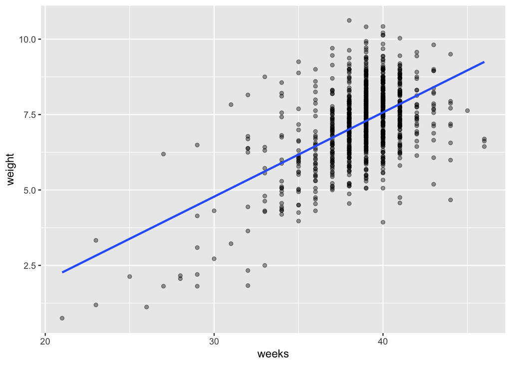

```r
births <- births14 |>
  drop_na(weeks, weight, mage)

ggplot(births, aes(x = weeks, y = weight)) +
  geom_point(alpha = 0.4) +
  geom_smooth(method = "lm", se = FALSE)
```

### Fit with `lm()`

The formula reads “response ~ explanatory”:

```r
fit <- lm(weight ~ weeks, data = births)
fit
```

```
Call:
lm(formula = weight ~ weeks, data = births)

Coefficients:
(Intercept)        weeks
    -3.5980       0.2792
```

`summary()` is the classic view; `broom::tidy()` returns the same table as a data frame you can pipe, filter, and plot:

```r
summary(fit)
```

```
Call:
lm(formula = weight ~ weeks, data = births)

Residuals:
    Min      1Q  Median      3Q     Max
-4.0175 -0.7187  0.0190  0.6886  3.6078

Coefficients:
            Estimate Std. Error t value Pr(>|t|)
(Intercept) -3.59797    0.52273  -6.883 1.03e-11 ***
weeks        0.27922    0.01349  20.699  < 2e-16 ***
---
Signif. codes:  0 '***' 0.001 '**' 0.01 '*' 0.05 '.' 0.1 ' ' 1

Residual standard error: 1.094 on 998 degrees of freedom
Multiple R-squared:  0.3004,    Adjusted R-squared:  0.2997
F-statistic: 428.4 on 1 and 998 DF,  p-value: < 2.2e-16
```

```r
tidy(fit)
```

```
# A tibble: 2 × 5
  term        estimate std.error statistic  p.value
  <chr>          <dbl>     <dbl>     <dbl>    <dbl>
1 (Intercept)   -3.60     0.523      -6.88 1.03e-11
2 weeks          0.279    0.0135     20.7  1.80e-79
```

Match each column of `tidy(fit)` to the lecture:

| Column | Lecture name |
| --- | --- |
| `estimate` | $b_0$, $b_1$ |
| `std.error` | $SE$ of the estimate |
| `statistic` | $T = (\text{estimate} - 0)/SE$ |
| `p.value` | two-sided p-value for $H_0: \beta = 0$ |

### Check the T statistic by hand

```r
tidy(fit) |>
  mutate(T_by_hand = estimate / std.error)
```

```
# A tibble: 2 × 6
  term        estimate std.error statistic  p.value T_by_hand
  <chr>          <dbl>     <dbl>     <dbl>    <dbl>     <dbl>
1 (Intercept)   -3.60     0.523      -6.88 1.03e-11     -6.88
2 weeks          0.279    0.0135     20.7  1.80e-79     20.7
```

### A confidence interval without any simulation

```r
tidy(fit, conf.int = TRUE, conf.level = 0.95)
```

```
# A tibble: 2 × 7
  term        estimate std.error statistic  p.value conf.low conf.high
  <chr>          <dbl>     <dbl>     <dbl>    <dbl>    <dbl>     <dbl>
1 (Intercept)   -3.60     0.523      -6.88 1.03e-11   -4.62     -2.57
2 weeks          0.279    0.0135     20.7  1.80e-79    0.253     0.306
```

Now do it yourself with the formula $b_1 \pm t^*_{n-2} \times SE$:

```r
b1  <- tidy(fit) |> filter(term == "weeks") |> pull(estimate)
se1 <- tidy(fit) |> filter(term == "weeks") |> pull(std.error)
tstar <- qt(0.975, df = nrow(births) - 2)

c(lower = b1 - tstar * se1, upper = b1 + tstar * se1)
```

```
    lower     upper
0.2527442 0.3056860
```

**Questions**

1. Interpret the slope in context (units!).
2. Does the interval from `broom` match your hand calculation?
3. Why is the degrees of freedom $n - 2$?

### Check the conditions (LINE)

`augment()` adds fitted values and residuals to the data:

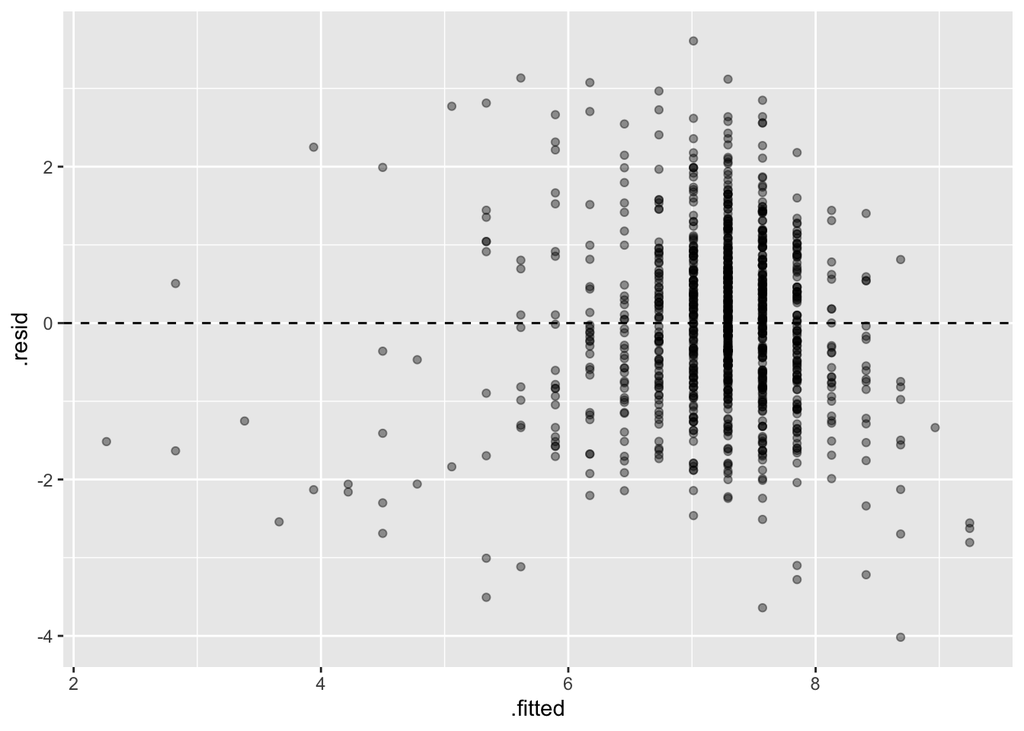

```r
aug <- augment(fit)

ggplot(aug, aes(x = .fitted, y = .resid)) +
  geom_point(alpha = 0.4) +
  geom_hline(yintercept = 0, linetype = "dashed")
```

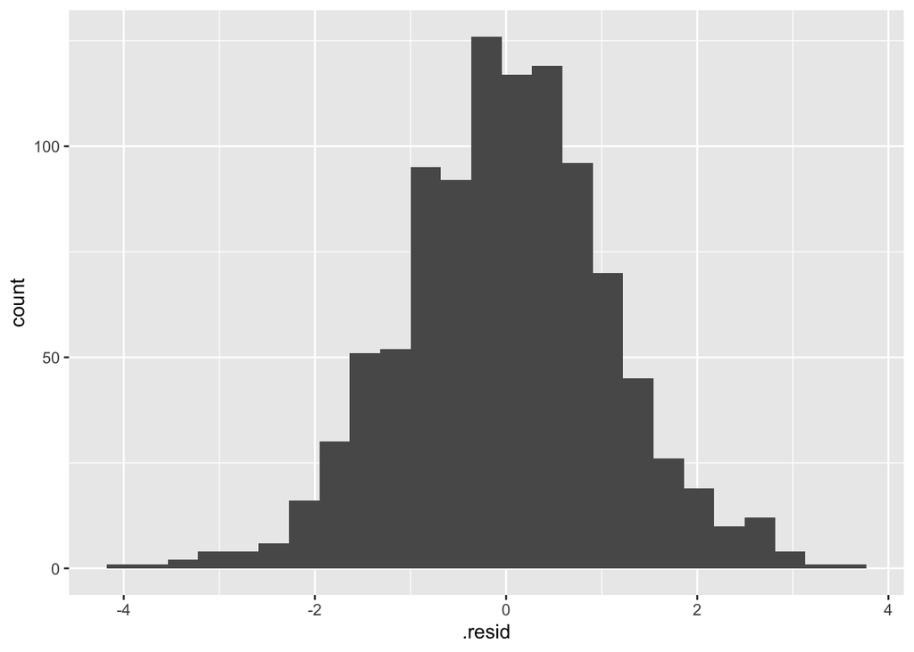

```r
ggplot(aug, aes(x = .resid)) +
  geom_histogram(bins = 25)
```

4. Look at the residual plot. Is there curvature? Does the spread change with the fitted value?
5. Look at the histogram of residuals. Is it roughly symmetric?
6. Which condition can you **not** check from a plot? (Hint: how were the births sampled?)

## Part 2: The old way, with `replicate()`

Before `infer`, recall how we simulated in the last lab. A permutation test for the slope in base tidyverse code:

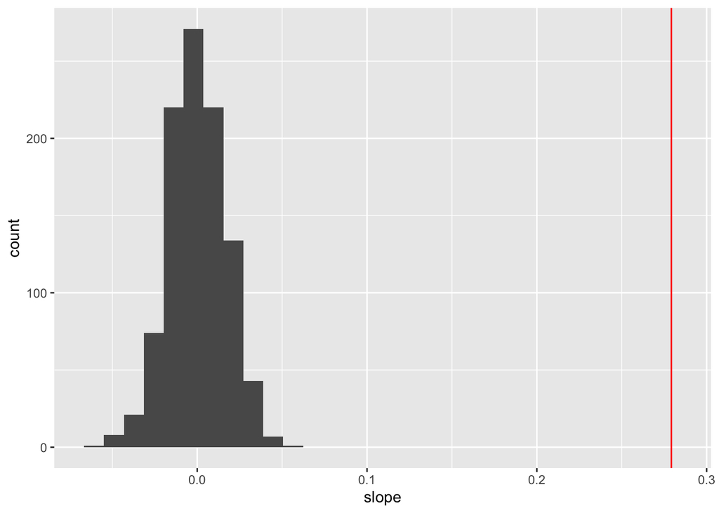

```r
obs_slope <- coef(lm(weight ~ weeks, data = births))[["weeks"]]

null_slopes <- replicate(1000, {
  shuffled <- births |> mutate(weight = sample(weight))
  coef(lm(weight ~ weeks, data = shuffled))[["weeks"]]
})

ggplot(tibble(slope = null_slopes), aes(x = slope)) +
  geom_histogram(bins = 30) +
  geom_vline(xintercept = obs_slope, color = "red")
```

```r
mean(abs(null_slopes) >= abs(obs_slope))   # two-sided p-value
```

```
[1] 0
```

This works, but you wrote the shuffle, the refit, and the p-value logic yourself. `infer` packages exactly these steps.

## Part 3: The infer grammar

`infer` expresses every inference problem as a pipeline:

| Verb | What it says |
| --- | --- |
| `specify()` | What are the variables? (`y ~ x`, or `response =`) |
| `hypothesize()` | What is the null? (skip this for a confidence interval) |
| `generate()` | Make many simulated datasets (`"permute"` or `"bootstrap"`) |
| `calculate()` | Compute the statistic on each one (`"slope"`, `"mean"`, `"diff in means"`, …) |

Then `visualize()`, `get_p_value()`, and `get_confidence_interval()` summarize the result.

**Rule of thumb:**

- *Testing* uses `hypothesize()` and `generate(type = "permute")` (or `"draw"` / `"simulate"` for other nulls).
- *Intervals* skip `hypothesize()` and use `generate(type = "bootstrap")`.

### Step 0: the observed statistic

Same pipeline, with no `hypothesize()` or `generate()`:

```r
obs_stat <- births |>
  specify(weight ~ weeks) |>
  calculate(stat = "slope")

obs_stat
```

```
Response: weight (numeric)
Explanatory: weeks (numeric)
# A tibble: 1 × 1
   stat
  <dbl>
1 0.279
```

Compare this number to `b1` above.

### Step 1: the null distribution

```r
null_dist <- births |>
  specify(weight ~ weeks) |>
  hypothesize(null = "independence") |>
  generate(reps = 1000, type = "permute") |>
  calculate(stat = "slope")

null_dist
```

```
Response: weight (numeric)
Explanatory: weeks (numeric)
Null Hypothesis: inde...
# A tibble: 1,000 × 2
   replicate       stat
       <int>      <dbl>
 1         1 -0.0000403
 2         2 -0.0308
 3         3  0.00132
 4         4 -0.0199
 5         5 -0.00203
 6         6 -0.0121
 7         7 -0.00505
 8         8  0.0146
 9         9 -0.00642
10        10 -0.0129
# ℹ 990 more rows
```

Read the pipeline aloud: *“Specify the model weight vs. weeks. Hypothesize that they are independent. Generate 1000 permuted datasets. Calculate the slope on each.”*

7. How many rows does `null_dist` have? What does each row represent?
8. Why is `"independence"` the right null here, and why does permuting work for it?

### Step 2: visualize and get the p-value

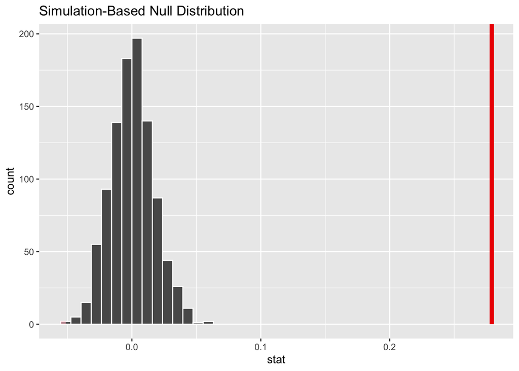

```r
visualize(null_dist) +
  shade_p_value(obs_stat = obs_stat, direction = "two-sided")
```

```r
null_dist |>
  get_p_value(obs_stat = obs_stat, direction = "two-sided")
```

```
# A tibble: 1 × 1
  p_value
    <dbl>
1       0
```

`infer` may print a note that the p-value is approximately zero; report it as “less than 1/1000” (with 1000 reps you cannot resolve smaller).

9. State your conclusion in context at $\alpha = 0.05$.

### Step 3: a bootstrap confidence interval

Notice: **no `hypothesize()`**, and `type = "bootstrap"`.

```r
boot_dist <- births |>
  specify(weight ~ weeks) |>
  generate(reps = 1000, type = "bootstrap") |>
  calculate(stat = "slope")

percentile_ci <- boot_dist |>
  get_confidence_interval(level = 0.95, type = "percentile")

se_ci <- boot_dist |>
  get_confidence_interval(level = 0.95, type = "se", point_estimate = obs_stat)

percentile_ci
```

```
# A tibble: 1 × 2
  lower_ci upper_ci
     <dbl>    <dbl>
1    0.240    0.315
```

```r
se_ci
```

```
# A tibble: 1 × 2
  lower_ci upper_ci
     <dbl>    <dbl>
1    0.242    0.316
```

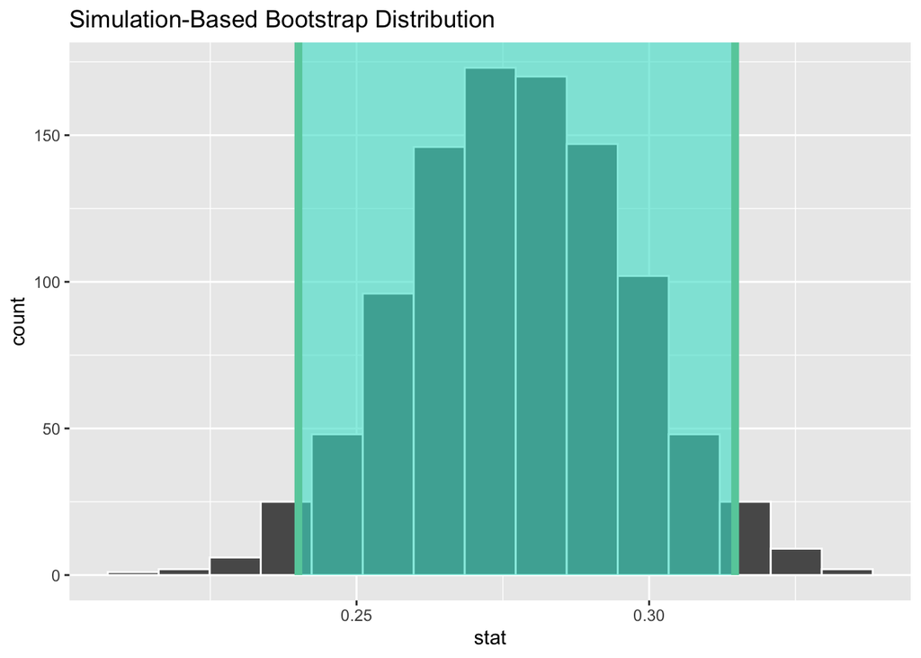

```r
visualize(boot_dist) +
  shade_confidence_interval(endpoints = percentile_ci)
```

10. Compare the percentile interval, the SE-based interval, and the `lm()` interval from Part 1. Are they close?
11. Why does the SE method need `point_estimate`, but the percentile method does not?

Now ask whether mother’s age predicts birth weight.

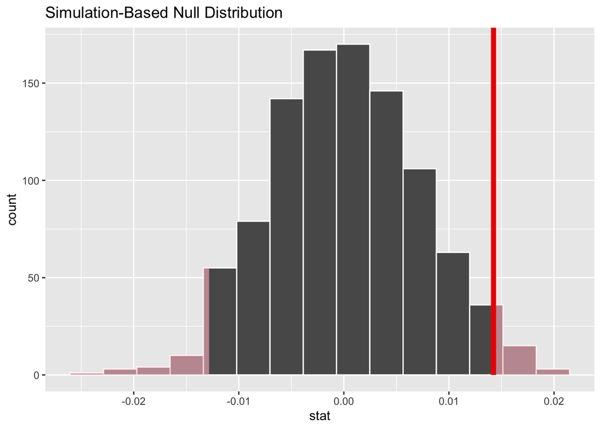

```r
obs_mage <- births |>
  specify(weight ~ mage) |>
  calculate(stat = "slope")

null_mage <- births |>
  specify(weight ~ mage) |>
  hypothesize(null = "independence") |>
  generate(reps = 1000, type = "permute") |>
  calculate(stat = "slope")

visualize(null_mage) +
  shade_p_value(obs_stat = obs_mage, direction = "two-sided")
```

```r
get_p_value(null_mage, obs_stat = obs_mage, direction = "two-sided")
```

```
# A tibble: 1 × 1
  p_value
    <dbl>
1   0.046
```

```r
boot_mage <- births |>
  specify(weight ~ mage) |>
  generate(reps = 1000, type = "bootstrap") |>
  calculate(stat = "slope")

get_confidence_interval(boot_mage, level = 0.95, type = "percentile")
```

```
# A tibble: 1 × 2
   lower_ci upper_ci
      <dbl>    <dbl>
1 -0.000875   0.0275
```

12. Does the interval contain 0? Does that agree with the p-value?
13. Compare with `tidy(lm(weight ~ mage, data = births))`. Do the three methods agree in their conclusion?

## Part 5: One grammar, many problems

The reason to learn `infer` is that the grammar does not change. Here is a difference in means, using the *same* four verbs:

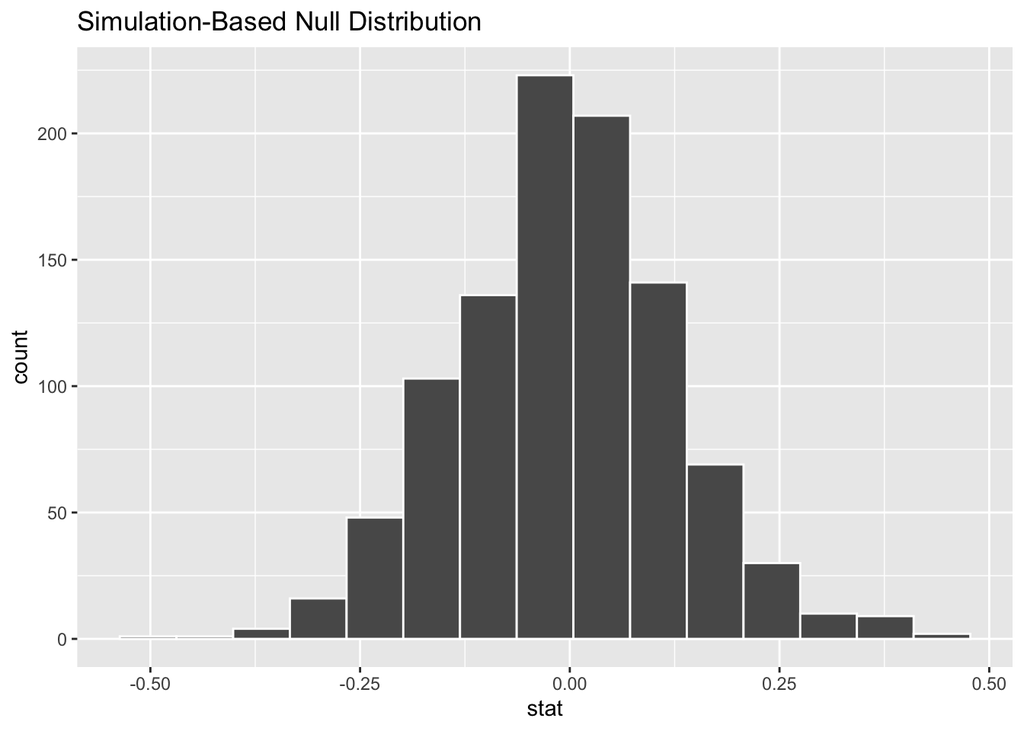

```r
births |>
  drop_na(habit) |>
  specify(weight ~ habit) |>
  hypothesize(null = "independence") |>
  generate(reps = 1000, type = "permute") |>
  calculate(stat = "diff in means", order = c("nonsmoker", "smoker")) |>
  visualize()
```

And a one-sample proportion (a point null, so the generate type changes):

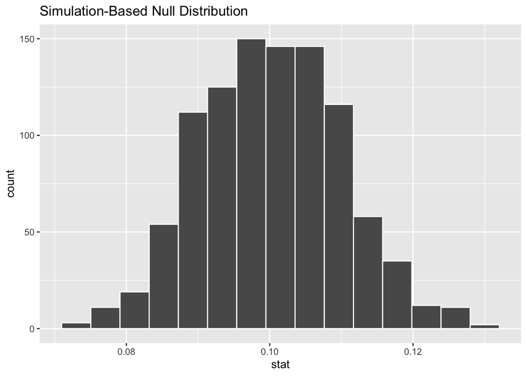

```r
births |>
  specify(response = premie, success = "premie") |>
  hypothesize(null = "point", p = 0.10) |>
  generate(reps = 1000, type = "draw") |>
  calculate(stat = "prop") |>
  visualize()
```

14. What changed between the slope pipeline and the difference-in-means pipeline? What stayed the same?

## Part 6: Your turn (Elmhurst College)

1. Make a scatterplot with a fitted line. Does the linear model look reasonable?
2. Fit `lm(gift_aid ~ family_income, data = elmhurst)` and report the slope, SE, T, and p-value with `tidy()`.
3. Write the `infer` pipeline for a **permutation test** of $H_0: \beta_1 = 0$ with 1000 reps. Report the p-value.
4. Write the `infer` pipeline for a **bootstrap 95% CI** for the slope (percentile).
5. Interpret the interval in context. Does it agree with the test?
6. Check the conditions with `augment()` plots. Which one worries you the most?

## Cheat sheet

```r
# observed statistic
data |> specify(y ~ x) |> calculate(stat = "slope")

# null distribution (test)
data |> specify(y ~ x) |>
  hypothesize(null = "independence") |>
  generate(reps = 1000, type = "permute") |>
  calculate(stat = "slope")

# bootstrap distribution (interval)
data |> specify(y ~ x) |>
  generate(reps = 1000, type = "bootstrap") |>
  calculate(stat = "slope")

# summaries
visualize(dist) + shade_p_value(obs_stat, direction = "two-sided")
get_p_value(dist, obs_stat, direction = "two-sided")
get_confidence_interval(dist, level = 0.95, type = "percentile")
get_confidence_interval(dist, level = 0.95, type = "se", point_estimate = obs_stat)
```